# Modeling the unknown distribution with maximum likelihood and method of moments

Cam Rondeau

11/3/2021

# 1 Introduction

Maximum likelihood (MLE) and method of moments (MM) are two common methods for constructing a model. In this blog post, I will write a tutorial in which I will explain how one might use MLE and MM to model Glycohemoglobin and height of adult females. The data will be from National Health and Nutrition Examination Survey 2009-2010 (NHANES). To do this, I will compare and contrast the two methods in addition to comparing and contrasting the choice of underlying distribution.

My tutorial will do the following things:  
1. Show how I calculated estimates of parameters  
2. Provide visuals that show the estimated distribution compared to the empirical distribution  
- Overlay estimated pdf onto histogram  
- Overlay estimated CDF onto eCDF  
- QQ plot (sample vs estimated dist)  
3. Explain how I calculated the median from the estimated distribution

# 2 Normal Distribution

First, I will show how to model Glycohemoglobin and height of adult females using both maximum likelihood (MLE) and method of moments (MM) with the normal distribution.

## 2.1 Maximum Likelihood

### 2.1.1 Estimate Parameters

We can first use MLE to model the Glycohemoglobin and height of adult females. To do this, we will estimate the parameters of the distribution such that the likelihood of such parameters producing the observed data is maximized. We can use the `mle` function to calculate such parameters, which I have done below for Glycohemoglobin and height.

```r
#Calculate parameters for Glycohemoglobin
nLL_gh <- function(mean, sd){
  fs <- dnorm(
        x = d1$gh
      , mean = mean
      , sd = sd
      , log = TRUE
    )
  -sum(fs)
}
fit_gh <- mle(
    nLL_gh
  , start = list(mean = 1, sd = 1)
  , method = "L-BFGS-B"
  , lower = c(0, 0.01)
)

mean_gh <- coef(fit_gh)[1]
sd_gh <- coef(fit_gh)[2]

sprintf("Glycohemoglobin mean using MLE: %f", mean_gh)
```

```
## [1] "Glycohemoglobin mean using MLE: 5.724600"
```

```r
sprintf("Glycohemoglobin standard deviation using MLE: %f", sd_gh)
```

```
## [1] "Glycohemoglobin standard deviation using MLE: 1.051720"
```

```r
#Calculate parameters for height
nLL_ht <- function(mean, sd){
  fs <- dnorm(
        x = d1$ht
      , mean = mean
      , sd = sd
      , log = TRUE
    )
  -sum(fs)
}
fit_ht <- mle(
    nLL_ht
  , start = list(mean = 1, sd = 1)
  , method = "L-BFGS-B"
  , lower = c(0, 0.01)
)

mean_ht <- coef(fit_ht)[1]
sd_ht <- coef(fit_ht)[2]

sprintf("Height mean using MLE: %f", mean_ht)
```

```
## [1] "Height mean using MLE: 160.741901"
```

```r
sprintf("Height standard deviation using MLE: %f", sd_ht)
```

```
## [1] "Height standard deviation using MLE: 7.316502"
```

### 2.1.2 Visualizations

Next, I will show what our estimated normal distribution with the calculated parameters looks like graphically, and I will compare that to the empirical distribution. I will do this for the PDF, CDF, and also create a QQ plot.

#### 2.1.2.1 PDF & CDF (With Estimated Median)

First, I will create a histogram from the data of both Glycohemoglobin and height, and then I will overlay the estimated pdf using the `dnorm` function and our estimated parameters for each set of data. Then, I will plot the eCDF of the data, and will overlay that with the estimated cdf using the `pnorm` function and our estimated parameters.

In addition to both plots, I will also calculate the median from the estimated distribution, and will overlay it on the plots. To do this, I will use the `qnorm` function and our estimated parameters. I will do this for both Glycohemoglobin and height.

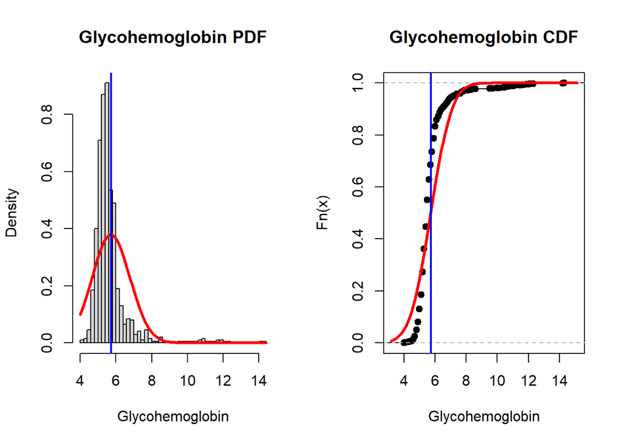

```r
#Calculate estimated median for Glycohemoglobin
gh_median <- qnorm(0.5, mean_gh, sd_gh)

par(mfrow=c(1,2))
#plot histogram/PDF Glycohemoglobin
hist(d1$gh, freq = FALSE,main="Glycohemoglobin PDF", xlab="Glycohemoglobin", breaks=50)
curve(dnorm(x, mean_gh, sd_gh), add=TRUE, lwd=3, col="red")
abline(v=gh_median, lwd=2, col="blue")

#plot ecdf/CDF Glycohemoglobin
plot(ecdf(d1$gh),main="Glycohemoglobin CDF", xlab="Glycohemoglobin")
curve(pnorm(x, mean_gh, sd_gh), add=TRUE, lwd=3, col="red")
abline(v=gh_median, lwd=2, col="blue")
```

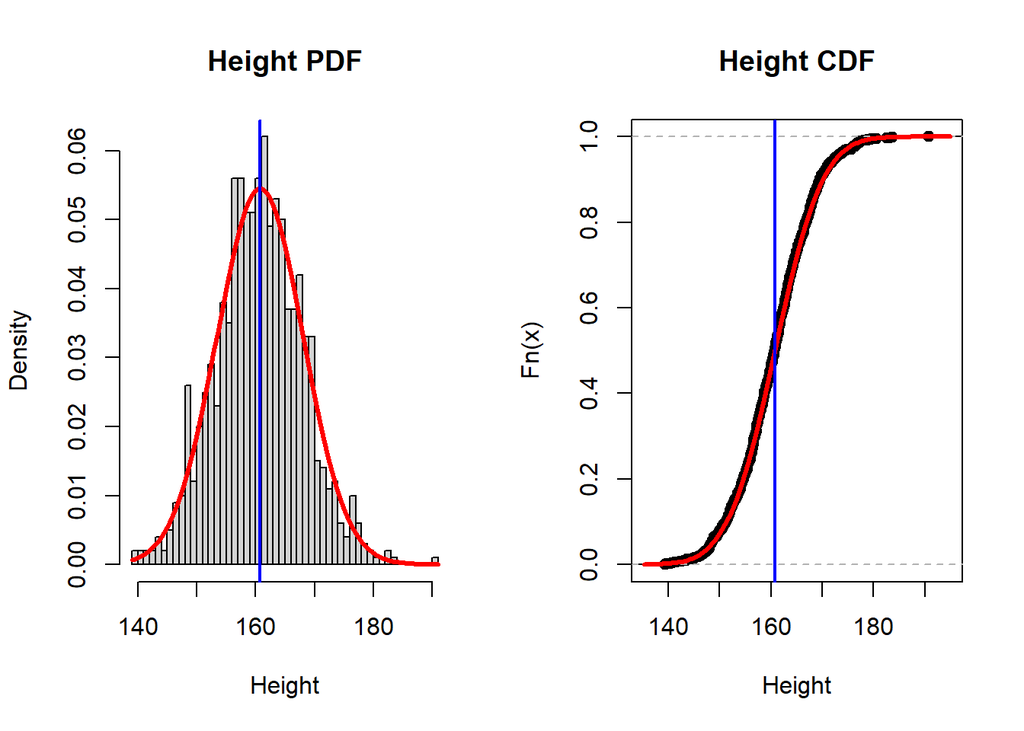

```r
#Calculate estimated median for height
ht_median <- qnorm(0.5, mean_ht, sd_ht)

par(mfrow=c(1,2))
#plot histogram/PDF height
hist(d1$ht, freq = FALSE,main="Height PDF", xlab="Height", breaks=50)
curve(dnorm(x, mean_ht, sd_ht), add=TRUE, lwd=3, col="red")
abline(v=ht_median, lwd=2, col="blue")

#plot ecdf/CDF  height
plot(ecdf(d1$ht),main="Height CDF", xlab="Height")
curve(pnorm(x, mean_ht, sd_ht), add=TRUE, lwd=3, col="red")
abline(v=ht_median, lwd=2, col="blue")
```

Using the normal distribution and MLE, the median of Glycohemoglobin is 5.72, and the median of height is 160.7.

The estimated model using MLE and a normal distribution does not create a PDF that lines up very well with the Glycohemoglobin levels of adult females. As you can see, the histogram is not symmetrical, and tails off to the right for a while, so a normal distribution is probably not the correct underlying distribution here. The estimated model using MLE and a normal distribution for height is much more accurate, and the estimated PDF lines up very well with the histogram of the data. Similar to the histograms and PDFs, you can see in the above graphs that the estimated CDF of Glycohemoglobin does not line up with the eCDF of the data well at all, whereas the estimated CDF of height lines up very well with the ecdf of the height data.

#### 2.1.2.2 QQ Plot

Finally, I will create a QQ plot to compare the empirical distribution and the estimated distribution. I will also do this for both Glycohemoglobin and height.

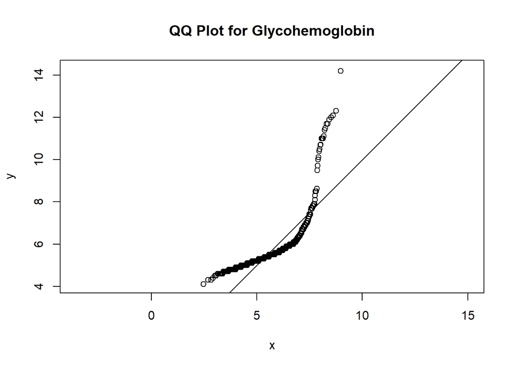

```r
#plot QQ plot Glycohemoglobin
x <- qnorm((1:1000)/1000, mean_gh, sd_gh)
y <- quantile(d1$gh, probs = (1:1000)/1000)
plot(x,y, asp=1, main="QQ Plot for Glycohemoglobin")
abline(0,1)
```

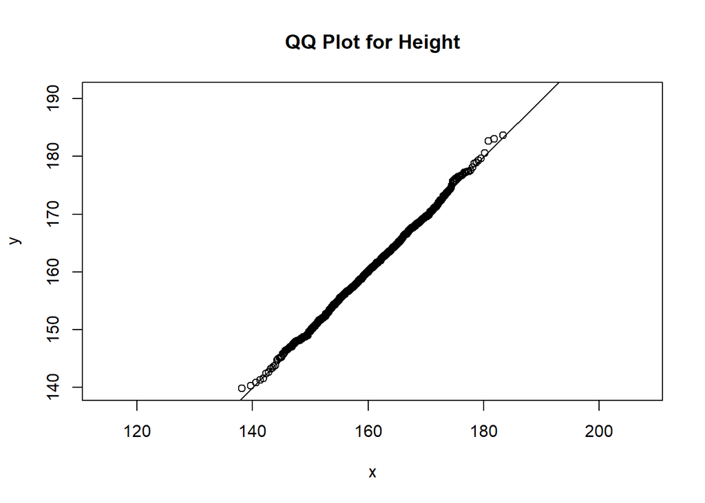

```r
#plot QQ plot height
x <- qnorm((1:1000)/1000, mean_ht, sd_ht)
y <- quantile(d1$ht, probs = (1:1000)/1000)
plot(x,y, asp=1, main="QQ Plot for Height")
abline(0,1)
```

As you can see above, the points on the Glycohemoglobin QQ plot do not fall on the y=x line very well at all, indicating that the normal distribution may not be the best fit, which we also saw in the CDF and PDF above.

The QQ plot for height is much more uniform, and more points fall much closer to the y=x line, indicating the normal distribution is a good fit, which also backs up the CDF and PDF plots above.

## 2.2 Method of Moments

### 2.2.1 Estimate Parameters

Second, I will use method of moments to show how to estimate parameters of the normal distribution. I know that for the normal distribution, mean = μ, and variance = $σ^2$. Therefore, we already know that the μ parameter is equal to the mean of the data. We can then calculate σ by taking the square root of the variance. We can do this for both Glycohemoglobin and height separately, which I have done in the code below.

```r
mean_gh <- mean(d1$gh)
var_gh <- var(d1$gh)
sd_gh <- sqrt(var_gh)

sprintf("Glycohemoglobin mean using MM: %f", mean_gh)
```

```
## [1] "Glycohemoglobin mean using MM: 5.724600"
```

```r
sprintf("Glycohemoglobin standard deviation using MM: %f", sd_gh)
```

```
## [1] "Glycohemoglobin standard deviation using MM: 1.052246"
```

```r
mean_ht <- mean(d1$ht)
var_ht <- var(d1$ht)
sd_ht <- sqrt(var_ht)

sprintf("Height mean using MM: %f", mean_ht)
```

```
## [1] "Height mean using MM: 160.741900"
```

```r
sprintf("Height standard deviation using MM: %f", sd_ht)
```

```
## [1] "Height standard deviation using MM: 7.320161"
```

### 2.2.2 Visualizations

Next, I will show what our estimated normal distribution with the calculated parameters looks like graphically, and I will compare that to the empirical distribution. I will do this for the PDF, CDF, and also create a QQ plot.

#### 2.2.2.1 PDF & CDF (With Estimated Median)

First, I will create a histogram from the data of both Glycohemoglobin and height, and then I will overlay the estimated pdf using the `dnorm` function and our estimated parameters for each set of data. Then, I will plot the eCDF of the data, and will overlay that with the estimated cdf using the `pnorm` function and our estimated parameters.

In addition to both plots, I will also calculate the median from the estimated distribution, and will overlay it on the plots. To do this, I will use the `qnorm` function and our estimated parameters. I will do this for both Glycohemoglobin and height.

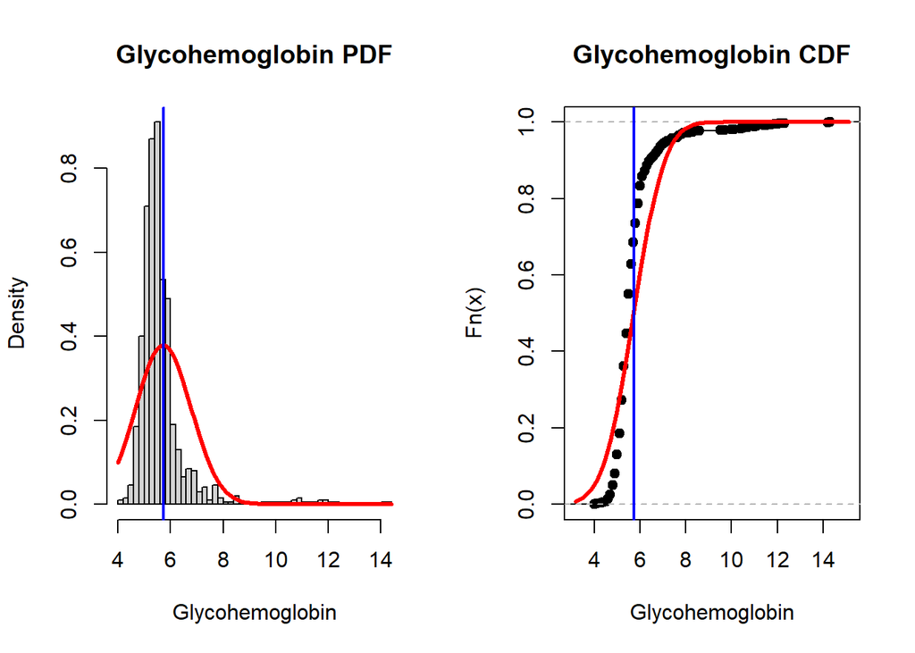

```r
#Calculate estimated median for Glycohemoglobin
gh_median <- qnorm(0.5, mean_gh, sd_gh)

par(mfrow=c(1,2))
#plot histogram/PDF Glycohemoglobin
hist(d1$gh, freq = FALSE,main="Glycohemoglobin PDF", xlab="Glycohemoglobin", breaks=50)
curve(dnorm(x, mean_gh, sd_gh), add=TRUE, lwd=3, col="red")
abline(v=gh_median, lwd=2, col="blue")

#plot ecdf/CDF Glycohemoglobin
plot(ecdf(d1$gh),main="Glycohemoglobin CDF", xlab="Glycohemoglobin")
curve(pnorm(x, mean_gh, sd_gh), add=TRUE, lwd=3, col="red")
abline(v=gh_median, lwd=2, col="blue")
```

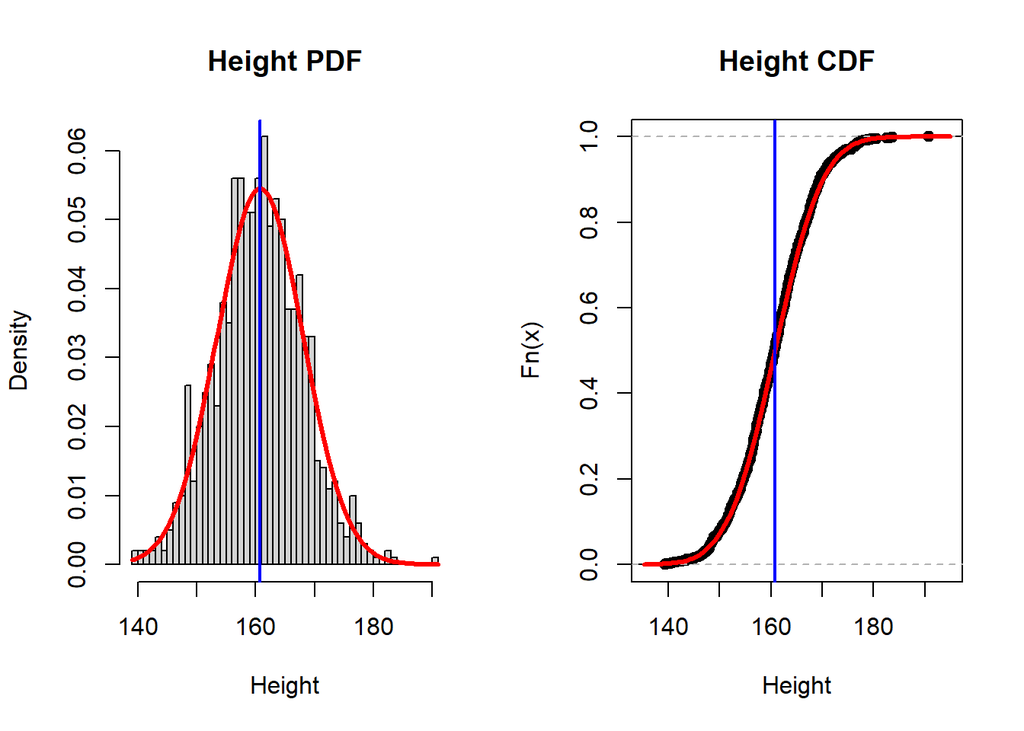

```r
#Calculate estimated median for height
ht_median <- qnorm(0.5, mean_ht, sd_ht)

par(mfrow=c(1,2))
#plot histogram/PDF height
hist(d1$ht, freq = FALSE,main="Height PDF", xlab="Height", breaks=50)
curve(dnorm(x, mean_ht, sd_ht), add=TRUE, lwd=3, col="red")
abline(v=ht_median, lwd=2, col="blue")

#plot ecdf/CDF  height
plot(ecdf(d1$ht),main="Height CDF", xlab="Height")
curve(pnorm(x, mean_ht, sd_ht), add=TRUE, lwd=3, col="red")
abline(v=ht_median, lwd=2, col="blue")
```

Using the normal distribution and MM, the median of Glycohemoglobin is 5.72, and the median of height is 160.7, which are the same exact values from using MLE.

The estimated model using MM and a normal distribution creates almost identical plots as the MLE method. Again, the Glycohemoglobin plots don’t line up as well as the height ones do, meaning that the normal distribution is probably not the right underlying distribution for Glycohemoglobin, but it definitely could be for height.

#### 2.2.2.2 QQ Plot

Finally, I will create a QQ plot to compare the empirical distribution and the estimated distribution. I will also do this for both Glycohemoglobin and height.

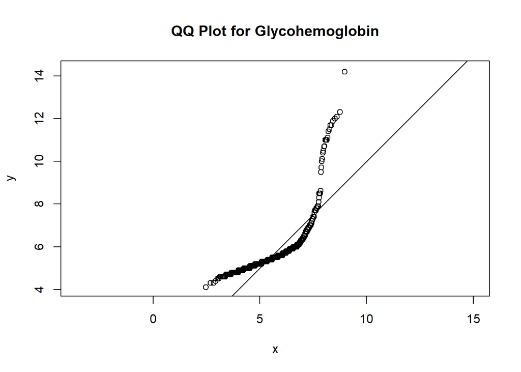

```r
#plot QQ plot Glycohemoglobin
x <- qnorm((1:1000)/1000, mean_gh, sd_gh)
y <- quantile(d1$gh, probs = (1:1000)/1000)
plot(x,y, asp=1, main="QQ Plot for Glycohemoglobin")
abline(0,1)
```

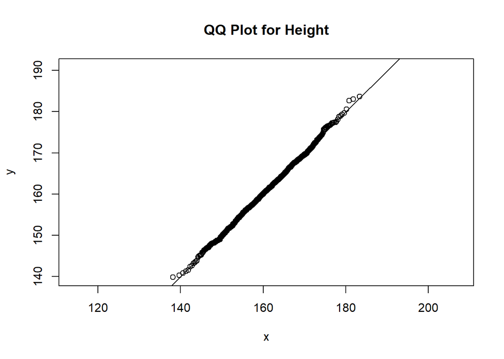

```r
#plot QQ plot height
x <- qnorm((1:1000)/1000, mean_ht, sd_ht)
y <- quantile(d1$ht, probs = (1:1000)/1000)
plot(x,y, asp=1, main="QQ Plot for Height")
abline(0,1)
```

The QQ plots are also identical to the MLE method, showing that Glycohemoglobin does not line up very well at all, but height does.

## 2.3 Conclusion

When using the normal curve as the underlying distribution, there was no difference between using the MLE or MM. In both cases, the estimated Glycohemoglobin plots did not line up with the data very well at all, but the estimated height plots did.

# 3 Gamma Distribution

Now, I will show how to model Glycohemoglobin and height of adult females using both maximum likelihood (MLE) and method of moments (MM) with the gamma distribution. I follow the same steps as I did above for the normal distribution, only this time I replace all `norm` functions with `gamma`.

## 3.1 Maximum Likelihood

### 3.1.1 Estimate Parameters

I will again use the `mle` function to calculate the maximized likelihood parameters shape and scale for both Glycohemoglobin and height.

```r
#Calculate parameters for Glycohemoglobin
nLL_gh <- function(shape, scale){
  fs <- dgamma(
        x = d1$gh
      , shape = shape
      , scale = scale
      , log = TRUE
    )
  -sum(fs)
}
fit_gh <- mle(
    nLL_gh
  , start = list(shape = 1, scale = 1)
  , method = "L-BFGS-B"
  , lower = c(0, 0.01)
)

shape_gh <- coef(fit_gh)[1]
scale_gh <- coef(fit_gh)[2]

sprintf("Glycohemoglobin shape using MLE: %f", shape_gh)
```

```
## [1] "Glycohemoglobin shape using MLE: 40.706505"
```

```r
sprintf("Glycohemoglobin scale using MLE: %f", scale_gh)
```

```
## [1] "Glycohemoglobin scale using MLE: 0.140636"
```

```r
#Calculate parameters for height
nLL_ht <- function(shape, scale){
  fs <- dgamma(
        x = d1$ht
      , shape = shape
      , scale = scale
      , log = TRUE
    )
  -sum(fs)
}
fit_ht <- mle(
    nLL_ht
  , start = list(shape = 1, scale = 1)
  , method = "L-BFGS-B"
  , lower = c(0, 0.01)
)

shape_ht <- coef(fit_ht)[1]
scale_ht <- coef(fit_ht)[2]

sprintf("Height shape using MLE: %f", shape_ht)
```

```
## [1] "Height shape using MLE: 479.646083"
```

```r
sprintf("Height scale using MLE: %f", scale_ht)
```

```
## [1] "Height scale using MLE: 0.335128"
```

### 3.1.2 Visualizations

Next, I will show what our estimated gamma distribution with the calculated parameters looks like graphically, and I will compare that to the empirical distribution. I will do this for the PDF, CDF, and also create a QQ plot.

#### 3.1.2.1 PDF & CDF (With Estimated Median)

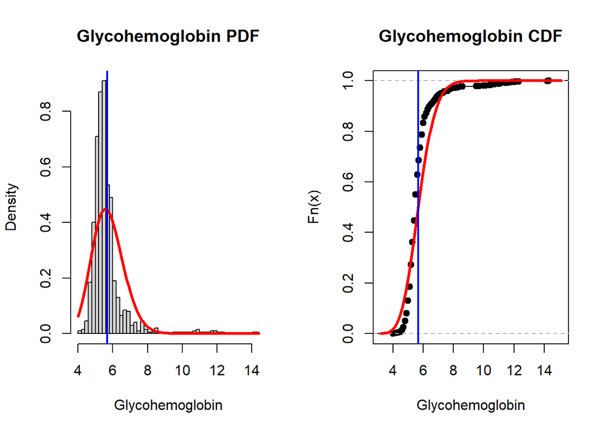

```r
#Calculate estimated median for Glycohemoglobin
gh_median <- qgamma(0.5, shape=shape_gh, scale=scale_gh)

par(mfrow=c(1,2))
#plot histogram/PDF Glycohemoglobin
hist(d1$gh, freq = FALSE,main="Glycohemoglobin PDF", xlab="Glycohemoglobin", breaks=50)
curve(dgamma(x, shape=shape_gh, scale=scale_gh), add=TRUE, lwd=3, col="red")
abline(v=gh_median, lwd=2, col="blue")

#plot ecdf/CDF Glycohemoglobin
plot(ecdf(d1$gh),main="Glycohemoglobin CDF", xlab="Glycohemoglobin")
curve(pgamma(x, shape=shape_gh, scale=scale_gh), add=TRUE, lwd=3, col="red")
abline(v=gh_median, lwd=2, col="blue")
```

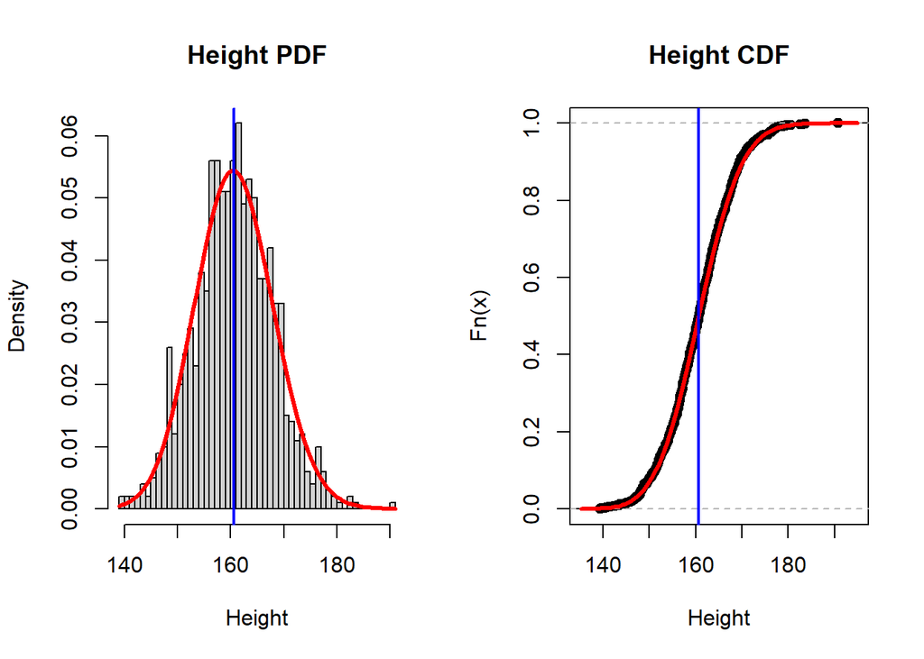

```r
#Calculate estimated median for height
ht_median <- qgamma(0.5, shape=shape_ht, scale=scale_ht)

par(mfrow=c(1,2))
#plot histogram/PDF height
hist(d1$ht, freq = FALSE,main="Height PDF", xlab="Height", breaks=50)
curve(dgamma(x, shape=shape_ht, scale=scale_ht), add=TRUE, lwd=3, col="red")
abline(v=ht_median, lwd=2, col="blue")

#plot ecdf/CDF  height
plot(ecdf(d1$ht),main="Height CDF", xlab="Height")
curve(pgamma(x, shape=shape_ht, scale=scale_ht), add=TRUE, lwd=3, col="red")
abline(v=ht_median, lwd=2, col="blue")
```

Using the gamma distribution and MLE, the median of Glycohemoglobin is 5.68, and the median of height is 160.6.

Similar to the normal distribution, the estimated model using MLE and a gamma distribution does not create a PDF or CDF estimate that line up very well with the empirical Glycohemoglobin data. Most of the Glycohemoglobin levels fall between 5 and 6, and the estimated gamma distribuion does not weigh this range of outputs heavily enough.

#### 3.1.2.2 QQ Plot

Finally, I will create a QQ plot to compare the empirical distribution and the estimated distribution. I will also do this for both Glycohemoglobin and height.

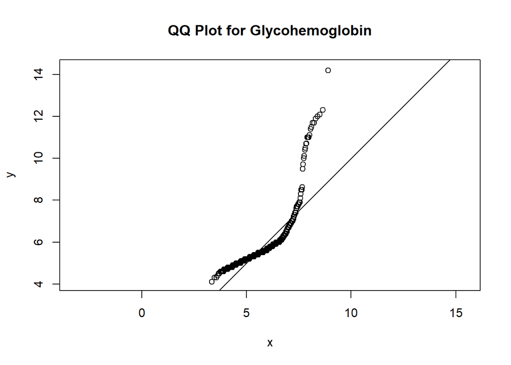

```r
#plot QQ plot Glycohemoglobin
x <- qgamma((1:1000)/1000, shape=shape_gh, scale=scale_gh)
y <- quantile(d1$gh, probs = (1:1000)/1000)
plot(x,y, asp=1, main="QQ Plot for Glycohemoglobin")
abline(0,1)
```

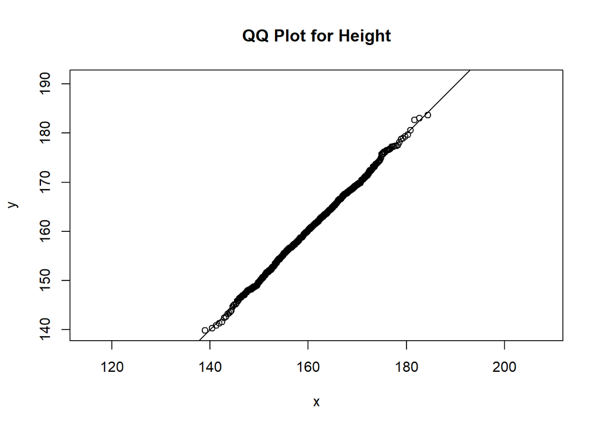

```r
#plot QQ plot height
x <- qgamma((1:1000)/1000, shape=shape_ht, scale=scale_ht)
y <- quantile(d1$ht, probs = (1:1000)/1000)
plot(x,y, asp=1, main="QQ Plot for Height")
abline(0,1)
```

## 3.2 Method of Moments

### 3.2.1 Estimate Parameters

Now, I will use method of moments to show how to estimate parameters of the gamma distribution. I know that for the gamma distribution, mean = shape * scale, and variance = shape * $scale^2$. Therefore, we can calculate that scale = variance / mean, and shape = mean$^2$ / variance. We can do this for both Glycohemoglobin and height separately, which I have done in the code below.

```r
mean_gh <- mean(d1$gh)
var_gh <- var(d1$gh)
shape_gh <- mean_gh^2/var_gh
scale_gh <- var_gh/mean_gh

sprintf("Glycohemoglobin shape using MM: %f", shape_gh)
```

```
## [1] "Glycohemoglobin shape using MM: 29.597536"
```

```r
sprintf("Glycohemoglobin scale using MM: %f", scale_gh)
```

```
## [1] "Glycohemoglobin scale using MM: 0.193415"
```

```r
mean_ht <- mean(d1$ht)
var_ht <- var(d1$ht)
shape_ht <- mean_ht^2/var_ht
scale_ht <- var_ht/mean_ht

sprintf("Height shape using MM: %f", shape_ht)
```

```
## [1] "Height shape using MM: 482.188571"
```

```r
sprintf("Height scale using MM: %f", scale_ht)
```

```
## [1] "Height scale using MM: 0.333359"
```

### 3.2.2 Visualizations

Next, I will show what our estimated normal distribution with the calculated parameters looks like graphically, and I will compare that to the empirical distribution. I will do this for the PDF, CDF, and also create a QQ plot.

#### 3.2.2.1 PDF & CDF (With Estimated Median)

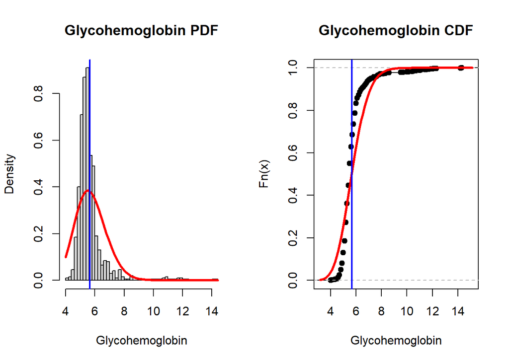

```r
#Calculate estimated median for Glycohemoglobin
gh_median <- qgamma(0.5, shape=shape_gh, scale=scale_gh)

par(mfrow=c(1,2))
#plot histogram/PDF Glycohemoglobin
hist(d1$gh, freq = FALSE,main="Glycohemoglobin PDF", xlab="Glycohemoglobin", breaks=50)
curve(dgamma(x, shape=shape_gh, scale=scale_gh), add=TRUE, lwd=3, col="red")
abline(v=gh_median, lwd=2, col="blue")

#plot ecdf/CDF Glycohemoglobin
plot(ecdf(d1$gh),main="Glycohemoglobin CDF", xlab="Glycohemoglobin")
curve(pgamma(x, shape=shape_gh, scale=scale_gh), add=TRUE, lwd=3, col="red")
abline(v=gh_median, lwd=2, col="blue")
```

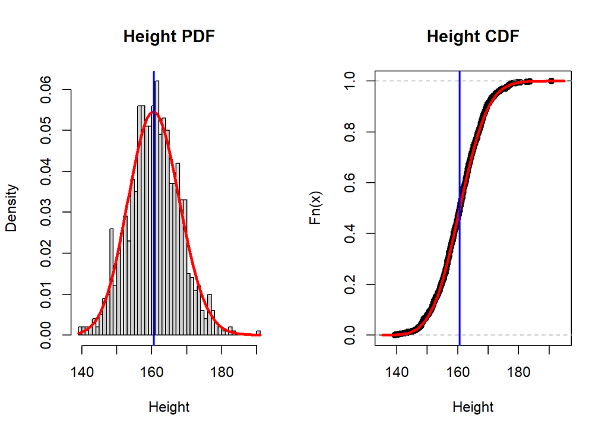

```r
#Calculate estimated median for height
ht_median <- qgamma(0.5, shape=shape_ht, scale=scale_ht)

par(mfrow=c(1,2))
#plot histogram/PDF height
hist(d1$ht, freq = FALSE,main="Height PDF", xlab="Height", breaks=50)
curve(dgamma(x, shape=shape_ht, scale=scale_ht), add=TRUE, lwd=3, col="red")
abline(v=ht_median, lwd=2, col="blue")

#plot ecdf/CDF  height
plot(ecdf(d1$ht),main="Height CDF", xlab="Height")
curve(pgamma(x, shape=shape_ht, scale=scale_ht), add=TRUE, lwd=3, col="red")
abline(v=ht_median, lwd=2, col="blue")
```

#### 3.2.2.2 QQ Plot

Finally, I will create a QQ plot to compare the empirical distribution and the estimated distribution. I will also do this for both Glycohemoglobin and height.

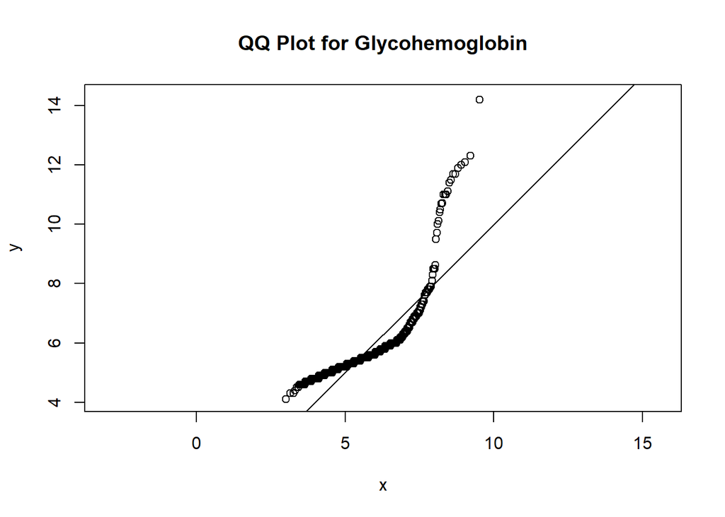

```r
#plot QQ plot Glycohemoglobin
x <- qgamma((1:1000)/1000, shape=shape_gh, scale=scale_gh)
y <- quantile(d1$gh, probs = (1:1000)/1000)
plot(x,y, asp=1, main="QQ Plot for Glycohemoglobin")
abline(0,1)
```

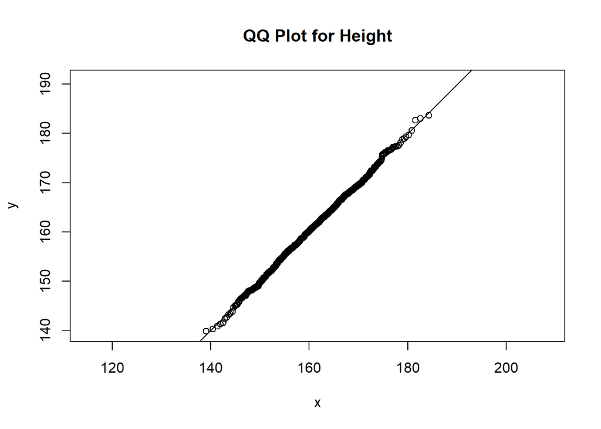

```r
#plot QQ plot height
x <- qgamma((1:1000)/1000, shape=shape_ht, scale=scale_ht)
y <- quantile(d1$ht, probs = (1:1000)/1000)
plot(x,y, asp=1, main="QQ Plot for Height")
abline(0,1)
```

The QQ plots are also identical to the MLE method, showing that Glycohemoglobin does not line up very well, but height does more so.

## 3.3 Conclusion

# 4 Weibull Distribution

Now, I will show how to model Glycohemoglobin and height of adult females using both maximum likelihood (MLE) and method of moments (MM) with the weibull distribution. I follow the same steps as I did above for the normal and gamma distributions, only this time I will use all `weibull` functions.

## 4.1 Maximum Likelihood

### 4.1.1 Estimate Parameters

I will again use the `mle` function to calculate the maximized likelihood parameters shape and scale for both Glycohemoglobin and height.

```r
#Calculate parameters for Glycohemoglobin
nLL_gh <- function(shape, scale){
  fs <- dweibull(
        x = d1$gh
      , shape = shape
      , scale = scale
      , log = TRUE
    )
  -sum(fs)
}
fit_gh <- mle(
    nLL_gh
  , start = list(shape = 1, scale = 1)
  , method = "L-BFGS-B"
  , lower = c(0, 0.01)
)

shape_gh <- coef(fit_gh)[1]
scale_gh <- coef(fit_gh)[2]

sprintf("Glycohemoglobin shape using MLE: %f", shape_gh)
```

```
## [1] "Glycohemoglobin shape using MLE: 4.125254"
```

```r
sprintf("Glycohemoglobin scale using MLE: %f", scale_gh)
```

```
## [1] "Glycohemoglobin scale using MLE: 6.173885"
```

```r
#Calculate parameters for height
nLL_ht <- function(shape, scale){
  fs <- dweibull(
        x = d1$ht
      , shape = shape
      , scale = scale
      , log = TRUE
    )
  -sum(fs)
}
fit_ht <- mle(
    nLL_ht
  , start = list(shape = 1, scale = 1)
  , method = "L-BFGS-B"
  , lower = c(0, 0.01)
)

shape_ht <- coef(fit_ht)[1]
scale_ht <- coef(fit_ht)[2]

sprintf("Height shape using MLE: %f", shape_ht)
```

```
## [1] "Height shape using MLE: 21.853979"
```

```r
sprintf("Height scale using MLE: %f", scale_ht)
```

```
## [1] "Height scale using MLE: 164.247192"
```

### 4.1.2 Visualizations

Next, I will show what our estimated weibull distribution with the calculated parameters looks like graphically, and I will compare that to the empirical distribution. I will do this for the PDF, CDF, and also create a QQ plot.

#### 4.1.2.1 PDF & CDF (With Estimated Median)

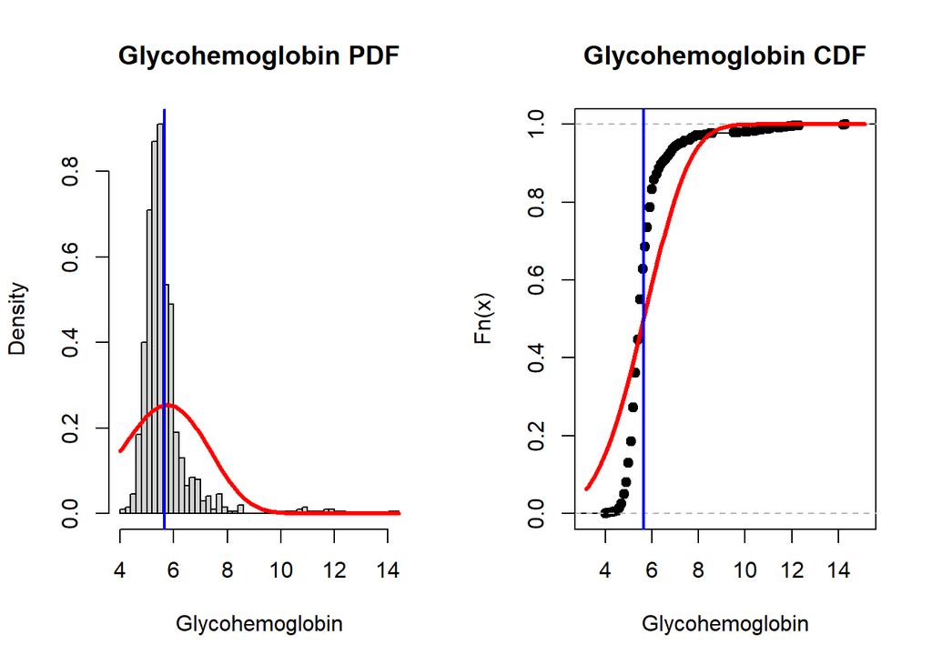

```r
#Calculate estimated median for Glycohemoglobin
gh_median <- qweibull(0.5, shape=shape_gh, scale=scale_gh)

par(mfrow=c(1,2))
#plot histogram/PDF Glycohemoglobin
hist(d1$gh, freq = FALSE,main="Glycohemoglobin PDF", xlab="Glycohemoglobin", breaks=50)
curve(dweibull(x, shape=shape_gh, scale=scale_gh), add=TRUE, lwd=3, col="red")
abline(v=gh_median, lwd=2, col="blue")

#plot ecdf/CDF Glycohemoglobin
plot(ecdf(d1$gh),main="Glycohemoglobin CDF", xlab="Glycohemoglobin")
curve(pweibull(x, shape=shape_gh, scale=scale_gh), add=TRUE, lwd=3, col="red")
abline(v=gh_median, lwd=2, col="blue")
```

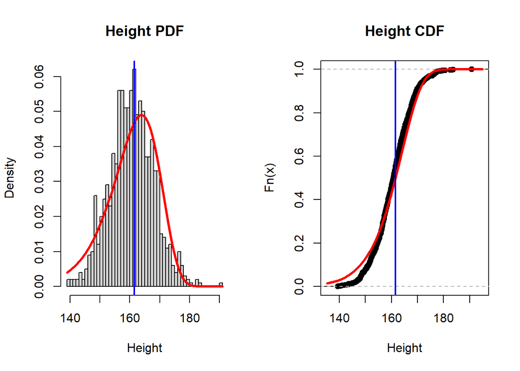

```r
#Calculate estimated median for height
ht_median <- qweibull(0.5, shape=shape_ht, scale=scale_ht)

par(mfrow=c(1,2))
#plot histogram/PDF height
hist(d1$ht, freq = FALSE,main="Height PDF", xlab="Height", breaks=50)
curve(dweibull(x, shape=shape_ht, scale=scale_ht), add=TRUE, lwd=3, col="red")
abline(v=ht_median, lwd=2, col="blue")

#plot ecdf/CDF  height
plot(ecdf(d1$ht),main="Height CDF", xlab="Height")
curve(pweibull(x, shape=shape_ht, scale=scale_ht), add=TRUE, lwd=3, col="red")
abline(v=ht_median, lwd=2, col="blue")
```

Using the weibull distribution and MLE, the median of Glycohemoglobin is 5.64, and the median of height is 161.5.

#### 4.1.2.2 QQ Plot

Finally, I will create a QQ plot to compare the empirical distribution and the estimated distribution. I will also do this for both Glycohemoglobin and height.

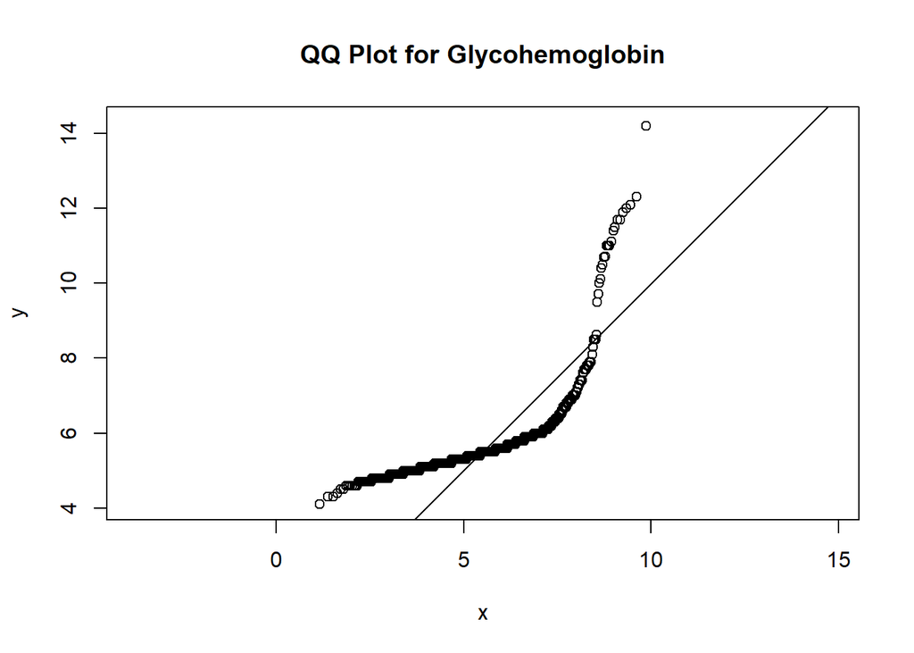

```r
#plot QQ plot Glycohemoglobin
x <- qweibull((1:1000)/1000, shape=shape_gh, scale=scale_gh)
y <- quantile(d1$gh, probs = (1:1000)/1000)
plot(x,y, asp=1, main="QQ Plot for Glycohemoglobin")
abline(0,1)
```

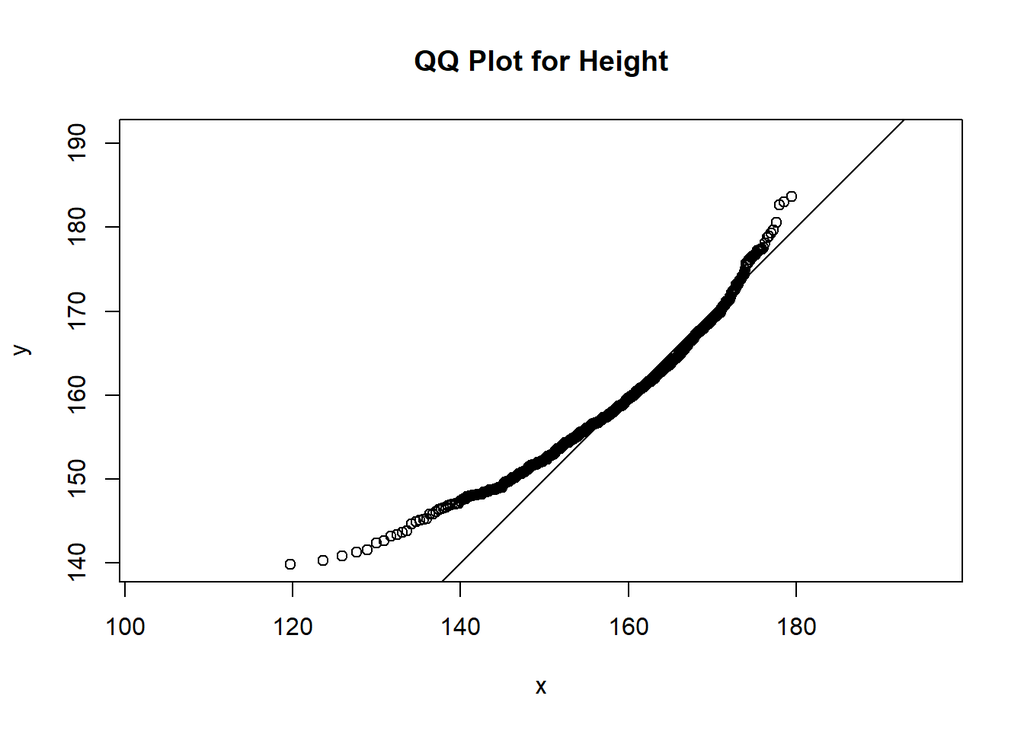

```r
#plot QQ plot height
x <- qweibull((1:1000)/1000, shape=shape_ht, scale=scale_ht)
y <- quantile(d1$ht, probs = (1:1000)/1000)
plot(x,y, asp=1, main="QQ Plot for Height")
abline(0,1)
```

As you can see above, the points on the Glycohemoglobin QQ plot and the height QQ plot both don’t line up well with the y=x line at all, indicating that neither variable can be estimated accurately with the Weibull distribution.

## 4.2 Method of Moments

### 4.2.1 Estimate Parameters

Now, I will use method of moments to show how to estimate parameters of the weibull distribution. I know that for the gamma distribution, mean = b Γ(1 + 1/a), and variance = b^2 * (Γ(1 + 2/a) - (Γ(1 + 1/a))^2), where shape = *a* and scale = *b*. Therefore, we can calculate scale and shape as per the below code. We can do this for both Glycohemoglobin and height separately.

```r
mean_gh <- mean(d1$gh)
sd_gh <- sd(d1$gh)


#solve for scale from mean equation
#scale_gh <- mean_gh/(gamma(1 + (1/shape)))

#plug scale equation into variance equation
#var_calc/mean_gh^2 = ((gamma(1 + (2/shape)))/(gamma(1 + (1/shape)))^2)-1

#Use estimate of above equations to find shape, then plug in for scale
shape_gh <- (sd_gh/mean_gh)^-1.086

#solve for scale from mean equation
scale_gh <- mean_gh/(gamma(1 + (1/shape_gh)))


sprintf("Glycohemoglobin shape using MM: %f", shape_gh)
```

```
## [1] "Glycohemoglobin shape using MM: 6.293493"
```

```r
sprintf("Glycohemoglobin scale using MM: %f", scale_gh)
```

```
## [1] "Glycohemoglobin scale using MM: 6.154462"
```

```r
mean_ht <- mean(d1$ht)
sd_ht <- sd(d1$ht)

#solve for scale from mean equation
#scale_gh <- mean_gh/(gamma(1 + (1/shape)))

#plug scale equation into variance equation
#var_calc/mean_gh^2 = ((gamma(1 + (2/shape)))/(gamma(1 + (1/shape)))^2)-1

#Use estimate of above equations to find shape, then plug in for scale
shape_ht <- (sd_ht/mean_ht)^-1.086

#solve for scale from mean equation
scale_ht <- mean_ht/(gamma(1 + (1/shape_ht)))

sprintf("Height shape using MM: %f", shape_ht)
```

```
## [1] "Height shape using MM: 28.640908"
```

```r
sprintf("Height scale using MM: %f", scale_ht)
```

```
## [1] "Height scale using MM: 163.852648"
```

The calculations for scale and shape of the Weibull distribution were taken from the paper “Methods for Estimating Wind Speed Frequency Distributions” by C.G. Justus, W.R. Hargraves, Amir Mikhail, and Denise Graber. (https://journals.ametsoc.org/view/journals/apme/17/3/1520-0450_1978_017_0350_mfewsf_2_0_co_2.xml)

### 4.2.2 Visualizations

Next, I will show what our estimated normal distribution with the calculated parameters looks like graphically, and I will compare that to the empirical distribution. I will do this for the PDF, CDF, and also create a QQ plot.

#### 4.2.2.1 PDF & CDF (With Estimated Median)

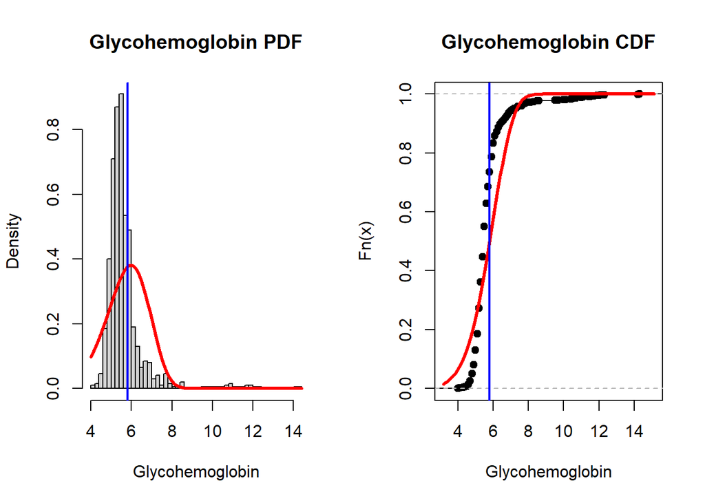

```r
#Calculate estimated median for Glycohemoglobin
gh_median <- qweibull(0.5, shape=shape_gh, scale=scale_gh)

par(mfrow=c(1,2))
#plot histogram/PDF Glycohemoglobin
hist(d1$gh, freq = FALSE,main="Glycohemoglobin PDF", xlab="Glycohemoglobin", breaks=50)
curve(dweibull(x, shape=shape_gh, scale=scale_gh), add=TRUE, lwd=3, col="red")
abline(v=gh_median, lwd=2, col="blue")

#plot ecdf/CDF Glycohemoglobin
plot(ecdf(d1$gh),main="Glycohemoglobin CDF", xlab="Glycohemoglobin")
curve(pweibull(x, shape=shape_gh, scale=scale_gh), add=TRUE, lwd=3, col="red")
abline(v=gh_median, lwd=2, col="blue")
```

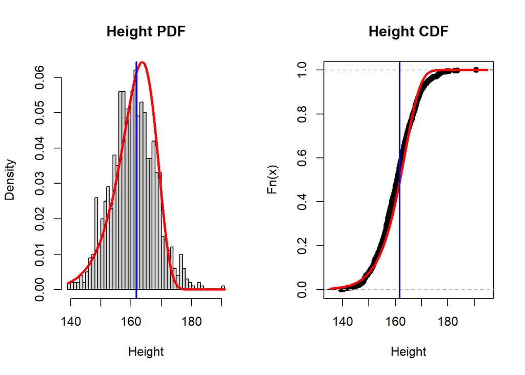

```r
#Calculate estimated median for height
ht_median <- qweibull(0.5, shape=shape_ht, scale=scale_ht)

par(mfrow=c(1,2))
#plot histogram/PDF height
hist(d1$ht, freq = FALSE,main="Height PDF", xlab="Height", breaks=50)
curve(dweibull(x, shape=shape_ht, scale=scale_ht), add=TRUE, lwd=3, col="red")
abline(v=ht_median, lwd=2, col="blue")

#plot ecdf/CDF  height
plot(ecdf(d1$ht),main="Height CDF", xlab="Height")
curve(pweibull(x, shape=shape_ht, scale=scale_ht), add=TRUE, lwd=3, col="red")
abline(v=ht_median, lwd=2, col="blue")
```

#### 4.2.2.2 QQ Plot

Finally, I will create a QQ plot to compare the empirical distribution and the estimated distribution. I will also do this for both Glycohemoglobin and height.

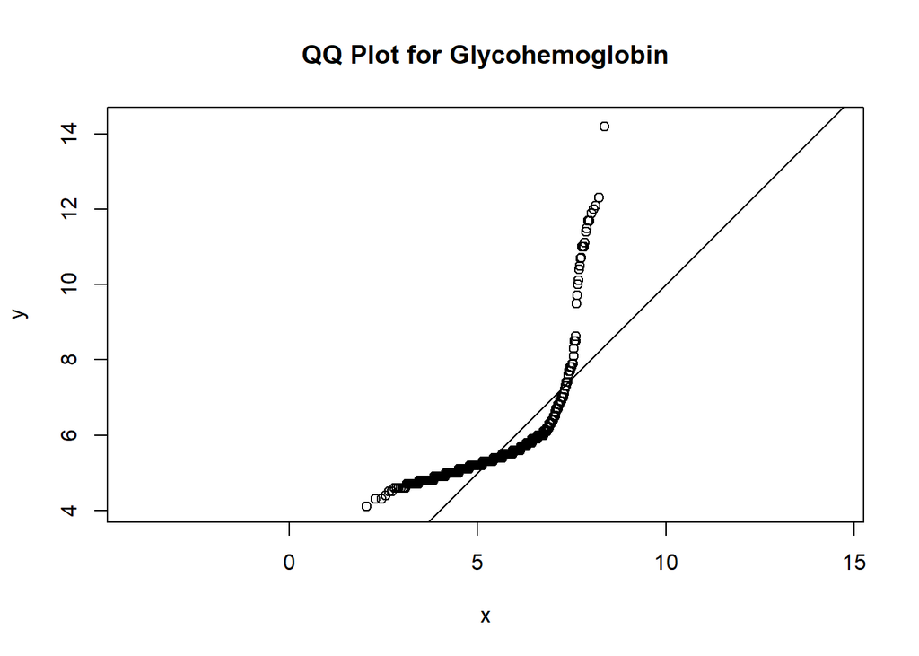

```r
#plot QQ plot Glycohemoglobin
x <- qweibull((1:1000)/1000, shape=shape_gh, scale=scale_gh)
y <- quantile(d1$gh, probs = (1:1000)/1000)
plot(x,y, asp=1, main="QQ Plot for Glycohemoglobin")
abline(0,1)
```

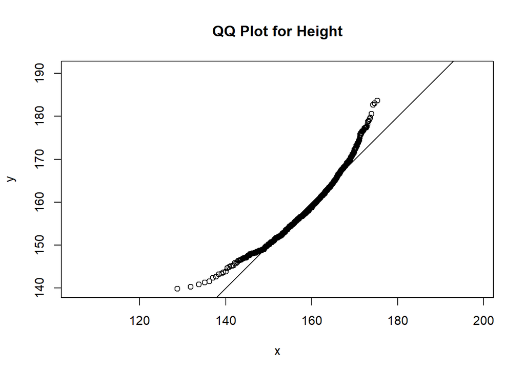

```r
#plot QQ plot height
x <- qweibull((1:1000)/1000, shape=shape_ht, scale=scale_ht)
y <- quantile(d1$ht, probs = (1:1000)/1000)
plot(x,y, asp=1, main="QQ Plot for Height")
abline(0,1)
```

## 4.3 Conclusion

When using the weibull curve as the underlying distribution, MLE and MM were very similar again. In both cases, the estimated Glycohemoglobin plots and height plots did not line up with with actual data very well.

# 5 Final Conclusion

I just walked through how to use maximum likelihood and method of moments to model the Glycohemoglobin and height of adult females using three separate underlying distributions. The one thing that stood out to me the most was that for each individual distribution, the resulting plots for MLE and MM were strikingly similar. That means that whether you use MLE or MM, you will estimate very similar distributions to model your data.

In terms of height, the normal distribution generated very accurate results, and it is definitely the right underlying distribution to model this data.